# Museums Need Money to Get Money

#### Cost sharing requirements may prevent some museums from pursuing federal grant programs

This project was completed during a course called “Design Lab: The Industry Challenge” as part of [MICA’s Data Analytics and Visualization program](https://online.mica.edu/dav/). The goal of the project is to take students through the design process from start to finish, which not only includes working with data and creating visualizations, but also iterating on the design by incorporating feedback from peers and instructors. Students were required to use data from the Urban Institute, but the topic itself was open-ended.

I chose to explore federal grants made to museums and similar institutions in the US. Partly because the data runs the gamut in terms of numerical, categorical, geospatial, etc., but mostly because I am a museum nerd. I have always enjoyed exploring new museums in new places and used this project as an opportunity to explore them from a different perspective.

Here is a quick summary of what I learned:

- Museums received over $100 million in grants from the IMLS between 2013 and 2022.
- Most of those grants went to museums with higher income.
- Museums with lower income may not be able to afford the matching funds required for most of the grant programs.

*Note - I’ll be using the term “museum” as a catch-all for museums, art galleries, botanical gardens, arboretums, nature centers, zoos, aquariums, and the like.*

#### Museum grants over the last 10 years

The Urban Institute led me to data from the [Institute of Museum and Library Services (IMLS)](https://imls.gov/), an independent agency of the federal government on a mission to, “advance, support, and empower America’s museums, libraries, and related organizations through grantmaking, research, and policy development.” The IMLS maintains a list of museums and associated information, last updated in 2018. The IMLS also makes data available regarding the grants they award to museums through various programs.

Although the grant data goes as far back as 1996 I decided to bound the time frame to the last 10 years (2013 - 2022). Over that time period the IMLS **awarded $101,674,483 through 628 grants** to museums in the US. The amount awarded each year see-sawed from 2013 to 2018 before **rising sharply in 2019**. It continues to increase through 2022, though at a slower rate.

I’ll unpack this further in the next section.

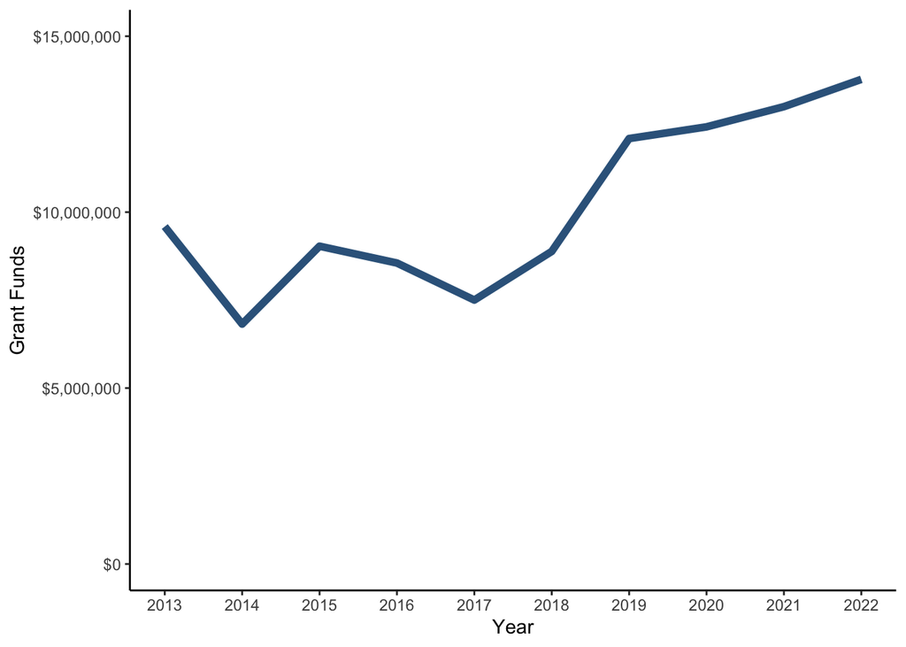

#### Where did all that funding go?

The 628 grants were awarded to **254 different museums**. Of those 254, 44% received one grant and the remaining **56% received multiple grants**. The American Museum of Natural History in New York tops the list both in terms of number of grants received (12) and the total funding received ($3,411,368).

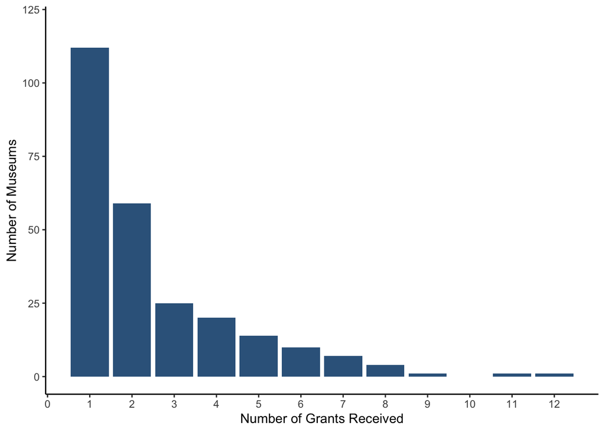

At the state level, museums in New York, Illinois, and California received the most funding. There weren’t any museums in South Dakota or Oklahoma that were awarded grants from the IMLS.

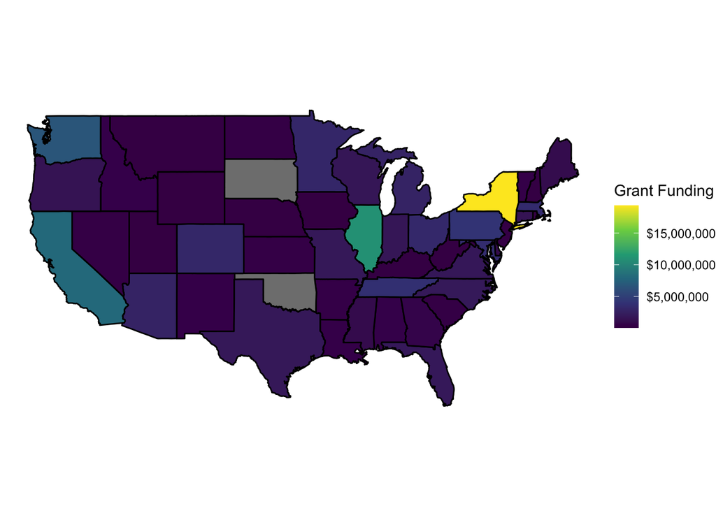

There’s a clear leader when comparing funding by museum discipline. **Nearly $30 million was awarded to art museums**, almost 50% more than the runner up, children’s museums. Botanical gardens, zoos/aquariums, and science museums received similar amounts. **History museums received the least** amount of funds with $6,201,416.

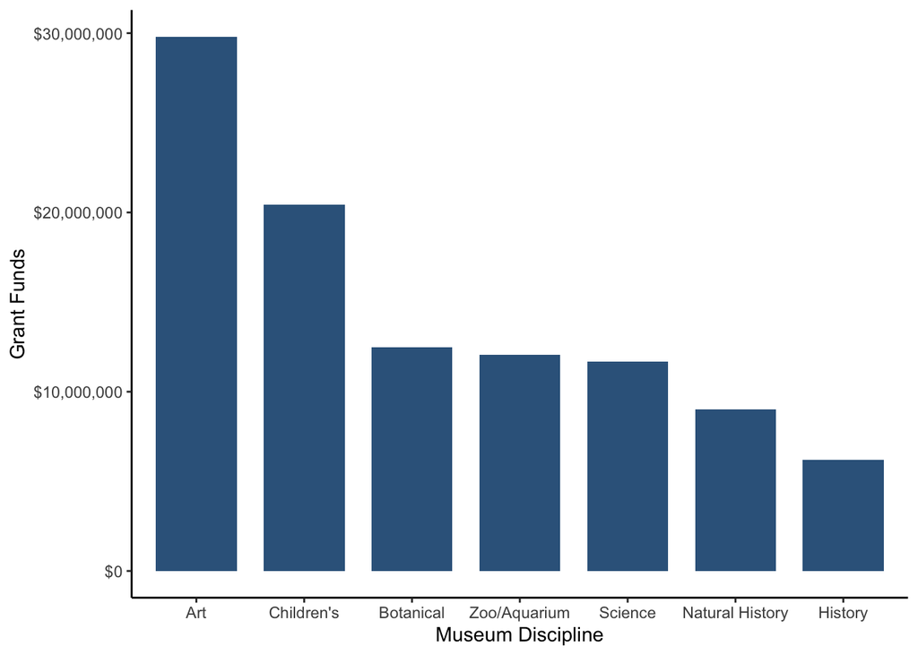

#### More funding went to museums with higher income

I was curious to see how the grants are distributed relative to income reported by the museums. Surprisingly, **more funding went to museums with higher income levels**. This contradicted my assumption that grants would go to institutions that needed funding, and that museums with higher income need less funding because they have the resources to support their initiatives.

I want to take a minute to explain how income levels will be represented throughout the article. The database maintained by the IMLS includes a single-digit IRS code related to the amount of income reported by the museum on their annual returns[^1]. A detailed breakdown of the codes is provided below, but just know that **the higher the number, the higher the income**.

| Income Level | Range |
| --- | --- |
| 0 | $0 |
| 1 | $1 - $9,999 |
| 2 | $10,000 - $24,999 |
| 3 | $25,000 - $99,999 |
| 4 | $100,000 - $499,999 |
| 5 | $500,000 - $999,999 |
| 6 | $1,000,000 - $4,999,999 |
| 7 | $5,000,000 - $9,999,999 |
| 8 | $10,000,000 - $49,999,999 |
| 9 | $50,000,000 to greater |

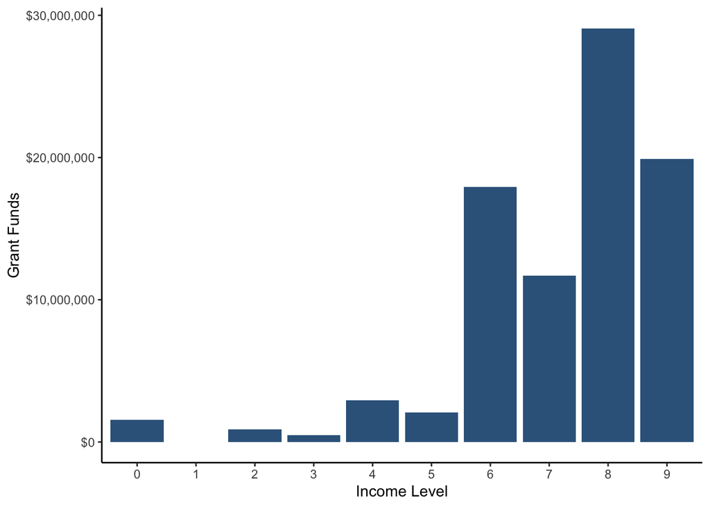

*Note - income data wasn’t available for 15% of the museums and they aren’t included in the chart above.*

#### But how does this compare to income levels across *all* museums?

Before diving deeper it’s worth comparing income levels of museums that received a grant to income levels of all museums in the IMLS data. By including the **6,726 museums that did not receive a grant** over the last 10 years the relative proportions for each income level are clear. There are **nearly 1,300 museums that reported zero income**, the largest group in the data. There’s a “bulge” in the middle income levels and another spike at the highest level, with **689 museums reporting over $50 million in income**. With this context it still appears that more grants were awarded to museums with higher income levels.

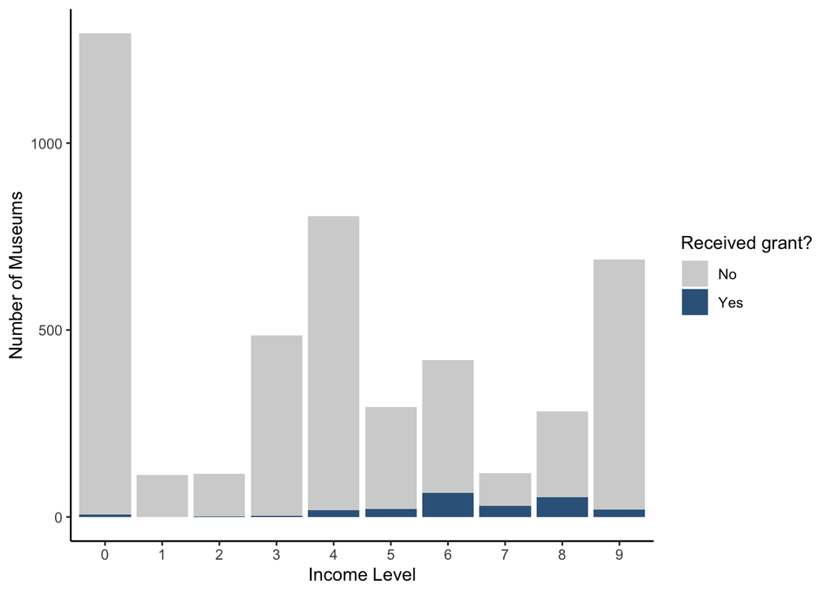

*Note - income data wasn’t available for 35% of the museums that did not receive a grant and they aren’t included in the chart above.*

#### Most grant programs require matching funds

Let’s look at how these grants are actually awarded. The IMLS has multiple grant programs with various eligibility criteria, funding amounts, and cost share requirements. In this data, the top four programs by funding awarded **represent 95% of the total funding** over the last 10 years. Of those, the top three require that the museum, “provide funds from non-federal sources in an amount that is equal to or greater than” the amount requested in the grant application. For example, if a museum applies for a $100,000 grant through the *Museums for America* program they must match that amount through other (non-federal) means.

| Rank | Program | Total Funds | Number of Grants | Requires Matching Funds? |
| --- | --- | --- | --- | --- |
| 1 | Museums for America | $70,578,719 | 465 | Yes |
| 2 | National Leadership Grants - Museums | $16,292,260 | 37 | Yes |
| 3 | Museums Empowered | $7,966,050 | 53 | Yes |
| 4 | Inspire! Grants for Small Museums | $2,141,872 | 46 | No |

Isolating each program confirms that the **top three programs skew towards higher income levels**. The *Inspire! Grants for Small Museums* program, which does not require matching funds, was awarded to museums with mid-range and lower income levels[^2].

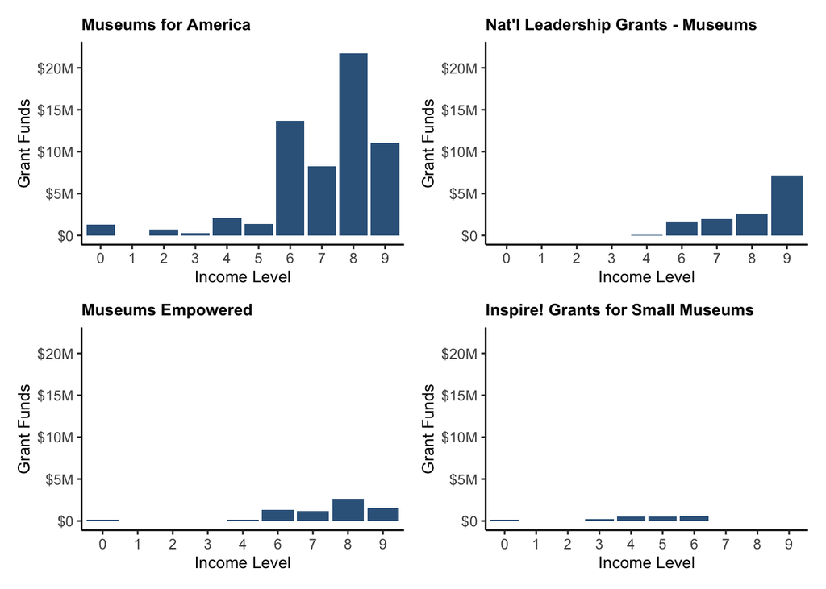

#### The burden of matching funds

The top three grant programs may skew towards higher income levels because **museums with lower income may not be able to afford the cost share requirements**, thus either making them ineligible or precluding them from applying in the first place. The *Inspire! Grants for Small Museums* may skew towards museums with lower income because they **don’t have to provide matching funds**.

I’ll use the median grant amount from the *Museums for America* program, rounded to $150,000, as a benchmark for comparison among the income levels. The representative income levels are the midpoint of the income range for each level, e.g. level 4 is $300,000. **Museums with income levels 0 to 3 make less than the $150,000 needed for matching funds**. At levels 4 and 5, museums’ income is over that amount, but not significantly so. Beyond that, museums have incomes orders of magnitude greater than the $150,000. For instance, **museums at the highest income level made at least 333x that amount**.

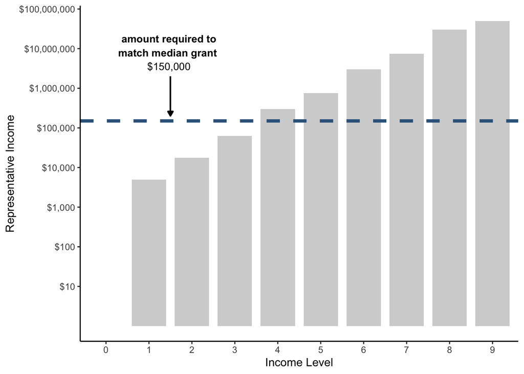

#### There should be more grants for museums with lower income

Museums provide critical economic, educational, and cultural benefits to their communities. They also support many conservation efforts. According to the American Alliance of Museums,

- Museums **return more than $5 in tax revenue for every $1 they receive in funding** from all levels of government
- Museums support over 726,000 jobs
- They receive approximately **55 million visits each year from students** in school groups
- More people visit art museums, science centers, historic houses or sites, zoos, or aquariums than attend professional sporting events
- Zoos and aquariums spent **$209 million on field conservation projects** in 117 countries in 2021

With these facts in mind I think it’s important that more grants be awarded to museums with lower income so that the communities in which they reside can benefit from all that these organizations have to offer. Here are a couple steps that the IMLS could take:

- Increase funding for the *Inspire! Grants for Small Museums* program to reach more museums
- Create new grant programs designed for museums with lower income regardless of size
- Modify cost sharing requirements required by other grant programs based on income level

On a more individual level, signing up for a membership or making a donation is another way to support your favorite museum. You could also reach out to your congressional representatives and let them know that you value museums so that they provide the IMLS with the resources required to support museums.

#### Sources

1. Urban Institute. 2020. Catalog of National Small-Area Data. Accessible from https://datacatalog.urban.org/dataset/catalog-national-small-area-data. Data developed at the Urban Institute, and made available under the ODC-BY 1.0 Attribution License.
2. Frehill, L. M. and Pelczar, M. (2018). *Data File Documentation: Museum Data Files, FY 2018 Release*. Institute of Museum and Library Services: Washington, DC. Accessible from https://imls.gov/research-evaluation/data-collection/museum-data-files.
3. IMLS. Awarded Grants data. Accessible from [https://imls.gov/grants/awarded-grants?field_recipient_type[Office+of+Museum+Services]=Office+of+Museum+Services](https://imls.gov/grants/awarded-grants?field_recipient_type%5BOffice+of+Museum+Services%5D=Office+of+Museum+Services).
4. American Alliance of Museums. Museum Facts & Data. https://www.aam-us.org/programs/about-museums/museum-facts-data/.

#### Methodology

The IMLS maintains a list of museums in the US in a set of files called the Museum Data Files (MDF). The MDF contain basic institutional identifying information for about 30,000 museums and related organizations in the US. They are split into three separate CSV files as follows:

1. Categorized museums, i.e. art, botanical gardens, history, science, etc. (7,429 entries)
2. Uncategorized or general museums (7,959 entries)
3. Historical societies and historic preservation (14,783 entries)

For this project I only used the first file from the MDF because the categorization provides another lens through which to look at the data, and to constrain it to a manageable scope.

I also downloaded grant data from the IMLS, specifically the Office of Museum Services. This includes the grant amount, year awarded, museum awarded, and grant program.

I then joined the MDF file and the grant data in R based on the name of the museum. If the museum name in the grant data didn’t find a matching museum in the MDF then it was dropped. There are a couple reasons why there wouldn’t be a match:

- The museum that received the grant is not in file #1, it’s in file #2 or #3
- The spelling of the name or nomenclature differed
- The museum is not in the MDF because it was established after 2018

I suspect the first bullet is the largest contributor because file #1 represents only about 25% of the museums in the MDF.

[Code repository on GitHub](https://github.com/john-h-knight/dav-design-lab-museums)

[^1]: The income code is based on the latest return filed with the IRS, as documented in the IRS Business Master File, May, 2015. While I don’t have income data for every year that I have grant data, I think it’s a reasonable benchmark to use for comparing museums.
[^2]: The [application information](https://imls.gov/grants/available/inspire-grants-small-museums) for this program explains that it is designed to support small museums, but it’s not clear how “small” is defined. If there is a correlation between size and income level, then museums with high income levels may not be eligible for this program. That could be one explanation for the distribution above. Unfortunately, the IMLS data doesn’t contain information regarding size.